# R Notebook

```r
library(tidyverse)
library(dplyr)
library(ggplot2)
library(car)
bird_data <- read_table("data/britain_species.txt", col_names = FALSE)
```

```r
bird <- bird_data %>%
  rename(Island = X1,
         Area = X2,
         Elevation = X3,
         Soil = X4,
         Latitude = X5,
         Distance = X6,
         Species = X7) %>%
  mutate(Area = as.double(Area),
         Elevation = as.integer(Elevation),
         Soil = as.integer(Soil),
         Latitude = as.double(Latitude),
         Distance = as.double(Distance),
         Species = as.integer(Species))
head(bird)
```

```r
bird.reg <- lm(Species ~ Area + Elevation + Soil + Latitude + Distance, data = bird)
```

## Collinearity

```r
temp_bird <- bird %>%
  select(-Island)

cor(temp_bird)
```

[output not shown]

## Multicollinearity

```r
vif(bird.reg)
```

[output not shown]

# Model Selection by Stepwise Regression

```r
step(bird.reg, direction = "both")
```

[output not shown]

# Partial F test Full/Reduced Model

H0: Beta1 (Area) = Beta2 (Elevation) = 0 | Ha: ALOI | Alpha = 0.05

```r
bird.reg1 <- lm(Species ~ Soil + Latitude + Distance, data = bird)

selcri <- function(lmout){
  n <- length(lmout$fit)
  rsq <- summary(lmout)$r.sq
  adj.rsq <- summary(lmout)$adj.r.sq
  aic <- extractAIC(lmout)[2]
  bic <- extractAIC(lmout, k = log(n))[2]
  press <- sum((lmout$residuals/(1 - hatvalues(lmout)))^2)
  cbind(rsq, adj.rsq, aic, bic, press)
}
anova(bird.reg1, bird.reg)
```

```
Analysis of Variance Table

Model 1: Species ~ Soil + Latitude + Distance
Model 2: Species ~ Area + Elevation + Soil + Latitude + Distance
  Res.Df    RSS Df Sum of Sq      F Pr(>F)
1     38 501761
2     36 482246  2     19515 0.7284 0.4896
```

Because the p value = 0.4896 > alpha level = 0.05, we fail to reject the null hypothesis and chose the reduced model by dropping the Area and Elevation variables from the model.

```r
selcri(bird.reg)
```

```
           rsq   adj.rsq      aic      bic     press
[1,] 0.8615934 0.8423703 404.6387 415.0647 182099529
```

```r
selcri(bird.reg1)
```

```
           rsq   adj.rsq      aic      bic    press
[1,] 0.8559924 0.8446234 402.3048 409.2555 681836.5
```

The Reduced Model statistically fits the data better because the adjusted R^2 is higher indicating higher correlation for the reduced model, and the AIC, BIC, and PRESS values are lower indicating there is less error

## Residuals

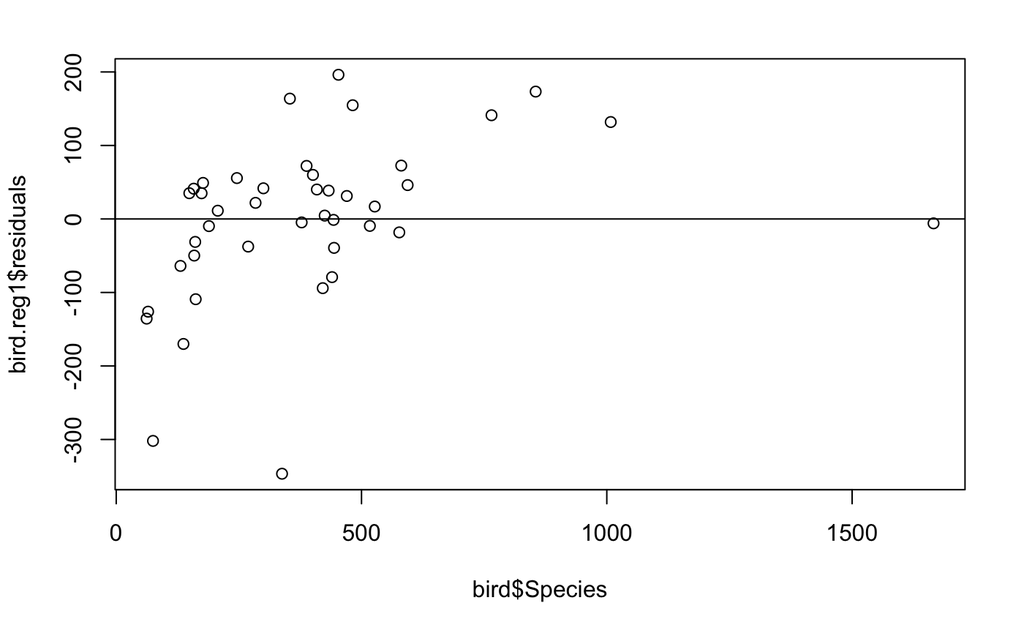

```r
plot(bird.reg1$residuals ~ bird$Species)
abline(0,0)
```

## QQPlot

```
[1]  1 20
```

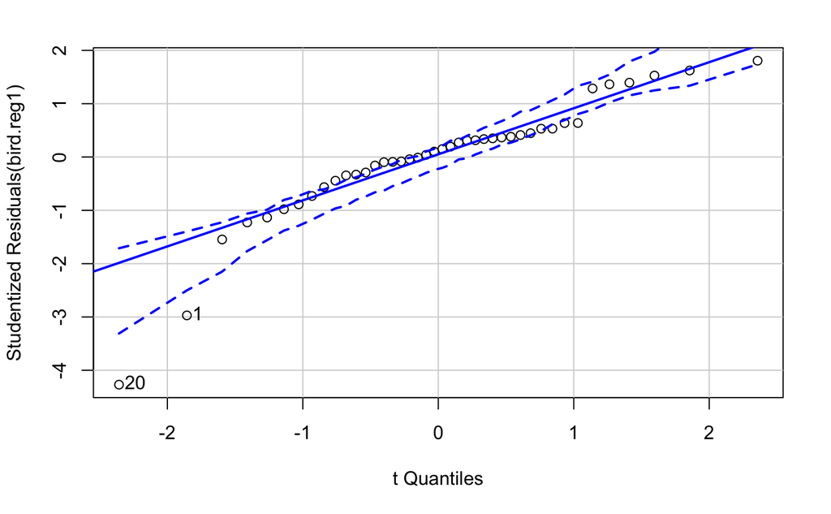

```r
qqPlot(bird.reg1)
```

# Full/Reduced Model without Britain

Hypothesis: Because Britain is such a large outlier in terms of its Area and Elevation compared to the other British isles, then if it were removed the new models would fit the data better

```r
NOBritainBird <- bird %>%
  filter(Island != "Britain")
NOBritainBird.reg <- lm(Species ~ Area + Elevation + Soil + Latitude + Distance, data = NOBritainBird)
step(NOBritainBird.reg, direction = "both")
```

[output not shown]

```r
NOBritainBird.reg1 <- lm(Species ~ Soil + Latitude + Distance, data = NOBritainBird)
anova(NOBritainBird.reg1, NOBritainBird.reg)
```

```
Analysis of Variance Table

Model 1: Species ~ Soil + Latitude + Distance
Model 2: Species ~ Area + Elevation + Soil + Latitude + Distance
  Res.Df    RSS Df Sum of Sq      F Pr(>F)
1     37 501635
2     35 472164  2     29472 1.0923 0.3466
```

H0: Beta1 (Area) = Beta2 (Elevation) = 0 | Ha: ALOI | Alpha = 0.05

Because the p value = 0.3466 > alpha level = 0.05, we fail to reject the null hypothesis and chose the reduced model by dropping the Area and Elevation variables from the model.

```r
selcri(NOBritainBird.reg)
```

```
           rsq   adj.rsq      aic      bic    press
[1,] 0.7408866 0.7038705 395.4119 405.6933 716910.5
```

```r
selcri(NOBritainBird.reg1)
```

```
           rsq   adj.rsq      aic      bic    press
[1,] 0.7247133 0.7023928 393.8943 400.7486 702150.3
```

```r
selcri(bird.reg1)
```

```
           rsq   adj.rsq      aic      bic    press
[1,] 0.8559924 0.8446234 402.3048 409.2555 681836.5
```

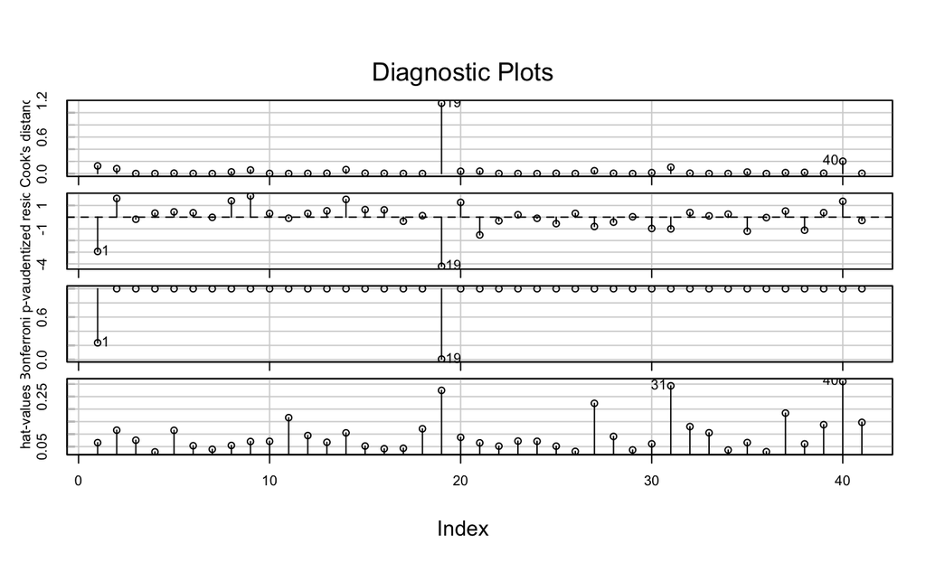

What can we conclude from this?